# INST 314 - Week 13 Lab - Spring 2021

04-27-2021

1. Chi-Square Analysis

1.Using R, load the data, check the variables, and find those that you will need to create a contingency table for showing top choice of water versus their usual water source. Label your rows and columns. Include as many additional code chunks and explanation areas as needed

```r
#load data
WaterTaste <- read.csv("C:/Users/kevin/Downloads/WaterTaste.csv")
library(tidyverse)
library(ggpubr)
library(car)
library(pwr)
library(dplyr)
library(ggplot2)


#Count function was used to produce the numbers in contingency table
count(WaterTaste,WaterTaste$UsuallyDrink == "Filtered" & WaterTaste$First == "Aqua")
```

| WaterTaste$UsuallyDrink == "Filtered" & WaterTaste$First == "Aqua" | n |
| --- | --- |
| FALSE | 100 |

```r
count(WaterTaste,WaterTaste$UsuallyDrink == "Filtered" &  WaterTaste$First == "Aquafina")
```

| WaterTaste$UsuallyDrink == "Filtered" & WaterTaste$First == "Aquafina" | n |
| --- | --- |
| FALSE | 96 |
| TRUE | 4 |

```r
count(WaterTaste,WaterTaste$UsuallyDrink == "Filtered" &  WaterTaste$First == "Sams")
```

| WaterTaste$UsuallyDrink == "Filtered" & WaterTaste$First == "Sams" | n |
| --- | --- |
| FALSE | 100 |

```r
count(WaterTaste,WaterTaste$UsuallyDrink == "Filtered" &  WaterTaste$First == "SamsChoice")
```

| WaterTaste$UsuallyDrink == "Filtered" & WaterTaste$First == "SamsChoice" | n |
| --- | --- |
| FALSE | 91 |
| TRUE | 9 |

```r
count(WaterTaste,WaterTaste$UsuallyDrink == "Filtered" &  WaterTaste$First == "Tap")
```

| WaterTaste$UsuallyDrink == "Filtered" & WaterTaste$First == "Tap" | n |
| --- | --- |
| FALSE | 97 |
| TRUE | 3 |

```r
count(WaterTaste,WaterTaste$UsuallyDrink == "Tap" &  WaterTaste$First == "Fiji")
```

| WaterTaste$UsuallyDrink == "Tap" & WaterTaste$First == "Fiji" | n |
| --- | --- |
| FALSE | 84 |
| TRUE | 16 |

```r
count(WaterTaste,WaterTaste$UsuallyDrink == "Tap" &  WaterTaste$First == "Aquafina")
```

| WaterTaste$UsuallyDrink == "Tap" & WaterTaste$First == "Aquafina" | n |
| --- | --- |
| FALSE | 93 |
| TRUE | 7 |

```r
count(WaterTaste,WaterTaste$UsuallyDrink == "Tap" &  WaterTaste$First == "SamsChoice")
```

| WaterTaste$UsuallyDrink == "Tap" & WaterTaste$First == "SamsChoice" | n |
| --- | --- |
| FALSE | 93 |
| TRUE | 7 |

```r
count(WaterTaste,WaterTaste$UsuallyDrink == "Tap" &  WaterTaste$First == "Tap")
```

| WaterTaste$UsuallyDrink == "Tap" & WaterTaste$First == "Tap" | n |
| --- | --- |
| FALSE | 97 |
| TRUE | 3 |

```r
count(WaterTaste,WaterTaste$UsuallyDrink == "Bottled" &  WaterTaste$First == "Fiji")
```

| WaterTaste$UsuallyDrink == "Bottled" & WaterTaste$First == "Fiji" | n |
| --- | --- |
| FALSE | 85 |
| TRUE | 15 |

```r
count(WaterTaste,WaterTaste$UsuallyDrink == "Bottled" &  WaterTaste$First == "Aqua")
```

| WaterTaste$UsuallyDrink == "Bottled" & WaterTaste$First == "Aqua" | n |
| --- | --- |
| FALSE | 100 |

```r
count(WaterTaste,WaterTaste$UsuallyDrink == "Bottled" &  WaterTaste$First == "Aquafina")
```

| WaterTaste$UsuallyDrink == "Bottled" & WaterTaste$First == "Aquafina" | n |
| --- | --- |
| FALSE | 86 |
| TRUE | 14 |

```r
count(WaterTaste,WaterTaste$UsuallyDrink == "Bottled" &  WaterTaste$First == "SamsChoice")
```

| WaterTaste$UsuallyDrink == "Bottled" & WaterTaste$First == "SamsChoice" | n |
| --- | --- |
| FALSE | 92 |
| TRUE | 8 |

```r
count(WaterTaste,WaterTaste$UsuallyDrink == "Bottled" &  WaterTaste$First == "Tap")
```

| WaterTaste$UsuallyDrink == "Bottled" & WaterTaste$First == "Tap" | n |
| --- | --- |
| FALSE | 96 |
| TRUE | 4 |

```r
#Number from count functions are formed into contingency table "WaterTasteTable"
WaterTasteTable = matrix(c(10,4,9,3,16,7,7,3,15,14,8,4),byrow = TRUE, ncol = 4)
#Column names are added
colnames(WaterTasteTable)=c("Fiji","Aquafina","SamsChoice","Tap")
#Row names are added
rownames(WaterTasteTable)=c("Filtered", "Tap","Bottled")
```

2. State valid null and alternative hypotheses for the chi-square test of independence.

```r
#H0: Top choices for taste preference are not associated with whether or not people drink bottled water
#HA: Top choices for taste preference are associated with whether or not people drink bottled water
```

3. Using R, conduct a chi-square test of independence with this data.

```r
chisq.test(WaterTasteTable)
```

```
Chi-squared approximation may be incorrect
```

```
    Pearson's Chi-squared test

data:  WaterTasteTable
X-squared = 4.9725, df = 6, p-value = 0.5473
```

5. Based on your analysis, is there evidence that the top choices for taste preference are associated with whether or not people usually drink bottled water? If there is a significant association between these two variables, describe how they are related.

```r
#With a significance level of 0.05 and 6 degrees of freedom, the derived critical value is 12.592. My chi-squared test produced a chi-squared value of 4.9725 and a p-value of 0.5473. If I compare my chi-squared value to my critical value, we can see that it is significantly less (4.9725 < 12.592). We fail to reject the null hypothesis. Top choices for taste preference are not associated with whether or not people usually drink bottled water.
```

2. Analysis of Variance (ANOVA)

Load the data, check the variables, and find those that you will need for this assignment. Optional: Subset the dataset to only retain the variables that you need for this analysis.

```r
#load data
Cereal <- read.csv("C:/Users/kevin/Downloads/Cereal.csv")
#subset data
CerealFiber <- Cereal %>%
  select(1,2,8)
#convert char to numeric
CerealFiber$Fiber <- sapply(CerealFiber$Fiber, as.numeric)
```

1. Summarize your data.
1. Create a table of summary statistics, showing the sample size, mean, and standard deviation for each company.

```r
#Creating summary table
summary <- matrix(c(sum(CerealFiber$Company == "K"), mean(CerealFiber$Fiber[CerealFiber$Company == "K"]), sd(CerealFiber$Fiber[CerealFiber$Company == "K"]),  sum(CerealFiber$Company == "G"), mean(CerealFiber$Fiber[CerealFiber$Company == "G"]), sd(CerealFiber$Fiber[CerealFiber$Company == "Q"]), sum(CerealFiber$Company == "Q"), mean(CerealFiber$Fiber[CerealFiber$Company == "Q"]), sd(CerealFiber$Fiber[CerealFiber$Company == "Q"])), byrow = TRUE, ncol = 3)
#Adding Column Names2
colnames(summary) <-c("Sample Size","Mean","Standard Deviation")
#Adding Company Row Names
rownames(summary) <-c("Company K", "Company G", "Company Q")
summary
```

```
          Sample Size     Mean Standard Deviation
Company K          11 1.763636           2.349158
Company G          13 1.469231           2.174090
Company Q           6 2.566667           2.174090
```

2. Create a plot of side-by-side boxplots. Comment on whether you are seeing any potential differences in the mean number of grams of fiber per serving, based on the three different companies.

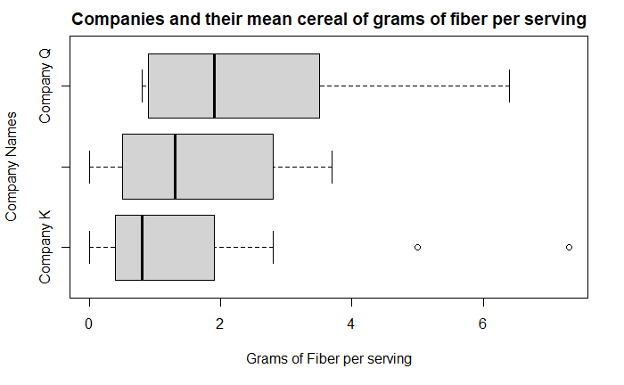

```r
K <- c((CerealFiber$Fiber[CerealFiber$Company =="K"]))
G <- c((CerealFiber$Fiber[CerealFiber$Company =="G"]))
Q <- c((CerealFiber$Fiber[CerealFiber$Company =="Q"]))
rownames(summary) <-c("Company K", "Company G", "Company Q")
Company <- c("Company K","Company C", "Company Q")
boxplot(K,G,Q,names=Company,horizontal = TRUE, main="Companies and their mean cereal of grams of fiber per serving", xlab = "Grams of Fiber per serving", ylab="Company Names")
```